# ACM con variables categóricas - Exoplanetas NASA

Daniel Alvarado - 145310

2026-10-18

# Introducción y objetivos

Este documento ejecuta la **Fase 5 anunciada en el ACP** (`ACP_Exoplanets.Rmd`): el **Análisis de Correspondencias Múltiples (ACM)** sobre las variables **categóricas** del catálogo de exoplanetas.

El principio es el mismo que se usó para las numéricas: **ninguna exclusión se decide por intuición**. Cada candidata pasa primero por un diagnóstico con datos (nulos, cardinalidad, nivel dominante) y solo después se decide si entra como activa, con qué tratamiento, o si queda excluida con la justificación exacta.

**Decisiones de alcance confirmadas antes de codear:**

1. El ACM corre sobre el **mismo subconjunto con masa (6.207 filas)** que el ACP, para que los dos análisis describan la misma población y `pl_bmassprov` (que solo existe en filas con masa) sea usable.
2. Los nulos categóricos se tratan como nivel propio **“Sin dato”** (no se descartan filas).
3. Los niveles con frecuencia menor a 100 se agrupan en **“Otros”**.
4. `default_flag` se **excluye**: es marcador de fila, no propiedad del planeta.

El catálogo completo (36.418 filas) se descarta como población: contiene varias filas de parámetros **por el mismo planeta** (es la estructura que detecta `default_flag`), así que en un ACM el mismo planeta contaría tantas veces como referencias tenga, distorsionando la tabla de perfiles.

```r
raw_data <- read.csv("data_descriptiva_multi/NASA_Exoplanet_Archive_Data.csv",
                     stringsAsFactors = FALSE)
cat("Registros originales:", nrow(raw_data), "\n")
```

```
## Registros originales: 36418
```

```r
cat("Columnas originales :", ncol(raw_data), "\n")
```

```
## Columnas originales : 91
```

# Fase 1 — Diagnóstico del universo categórico

## La estructura que condiciona todo: varias filas por planeta

Antes de mirar variables, hay que mirar la unidad de análisis. El catálogo **no** tiene una fila por planeta:

```r
d1 <- raw_data[raw_data$default_flag == 1, ]
tibble(
  concepto = c("Filas totales del catálogo",
               "Planetas únicos (pl_name distinto)",
               "Filas marcadas con default_flag = 1",
               "¿Exactamente una fila default por planeta?"),
  valor = c(nrow(raw_data),
            n_distinct(raw_data$pl_name),
            nrow(d1),
            if (n_distinct(d1$pl_name) == nrow(d1)) "Sí, sin duplicados" else "No")
) %>%
  kable(caption = "Estructura de la unidad de análisis del catálogo") %>%
  kable_styling(bootstrap_options = c("striped", "hover", "condensed"))
```

Estructura de la unidad de análisis del catálogo

| concepto | valor |
| --- | --- |
| Filas totales del catálogo | 36418 |
| Planetas únicos (pl_name distinto) | 5757 |
| Filas marcadas con default_flag = 1 | 5757 |
| ¿Exactamente una fila default por planeta? | Sí, sin duplicados |

`default_flag = 1` identifica **exactamente una fila por planeta** (las 5.757 filas default tienen 5.757 nombres distintos). El resto son conjuntos de parámetros alternativos de otras referencias. Esta es la razón formal para no correr el ACM sobre las 36.418 filas y para trabajar sobre el subconjunto con masa, donde la unidad es “registro de parámetros con masa” — la misma unidad que ya usa el ACP.

## Diagnóstico de las 18 candidatas

Todas las columnas que no son numéricas de contenido ni metadatos de precisión son candidatas: 18 en total.

```r
diag_global <- diagnostico_categoricas(raw_data)
diag_global %>%
  select(variable, pct_nulos, n_niveles, nivel_dominante, pct_dominante, problemas) %>%
  mutate(pct_nulos = paste0(pct_nulos, "%"), pct_dominante = paste0(pct_dominante, "%")) %>%
  kable(caption = "Diagnóstico de las 18 candidatas categóricas (catálogo completo)",
        col.names = c("Variable", "% nulos", "Niveles", "Dominante", "% dom.", "Veredicto automático")) %>%
  kable_styling(bootstrap_options = c("striped", "hover", "condensed"), full_width = FALSE) %>%
  column_spec(6, width = "32em")
```

Diagnóstico de las 18 candidatas categóricas (catálogo completo)

| Variable | % nulos | Niveles | Dominante | % dom. | Veredicto automático |
| --- | --- | --- | --- | --- | --- |
| discoverymethod | 0% | 11 | Transit | 90.2% | activa con agrupacion de raros |
| disc_facility | 0% | 70 | Kepler | 73.5% | activa con agrupacion de raros |
| soltype | 0% | 9 | Published Confirmed | 51.4% | activa sin tratamiento |
| pl_bmassprov | 83% | 3 | Mass | 11% | no viable: nulos estructurales (>=80%) |
| st_metratio | 38% | 3 | [Fe/H] | 51.1% | activa con agrupacion de raros |
| st_spectype | 92.8% | 275 | G0 V | 0.2% | no viable: nulos estructurales (>=80%) |
| ttv_flag | 0% | 2 | 0 | 89.3% | activa sin tratamiento |
| default_flag | 0% | 2 | 0 | 84.2% | marcador de fila, no propiedad del planeta |
| pl_name | 0% | 5757 | TrES-2 b | 0.1% | no viable: llave de identidad (sin significado categorico) |
| hostname | 0% | 4316 | Kepler-11 | 0.2% | no viable: llave de identidad (sin significado categorico) |
| pl_refname | 0% | 2221 | https://exoplanetarchive.ipac.caltech.edu/docs/Kepler_KOI_docs.html | 43.5% | no viable: llave de identidad (sin significado categorico) |
| st_refname | 1% | 2041 | https://exoplanetarchive.ipac.caltech.edu/docs/Kepler_KOI_docs.html | 37% | no viable: llave de identidad (sin significado categorico) |
| sy_refname | 0% | 192 | https://ui.adsabs.harvard.edu/abs/2019AJ….158..138S/abstract | 98% | no viable: un nivel domina >=95% |
| rastr | 0% | 4314 | 19h48m27.62s | 0.2% | no viable: continua o fecha (sin niveles naturales) |
| decstr | 0% | 4322 | +41d54m32.79s | 0.2% | no viable: continua o fecha (sin niveles naturales) |
| rowupdate | 0% | 461 | 2018-09-25 | 7.8% | no viable: continua o fecha (sin niveles naturales) |
| pl_pubdate | 0% | 289 | 2018-08-16 | 7.5% | no viable: continua o fecha (sin niveles naturales) |
| releasedate | 0% | 432 | 2018-09-25 | 7.5% | no viable: continua o fecha (sin niveles naturales) |

Este diagnóstico global sirve para conocer el catálogo, **pero las decisiones se toman con el diagnóstico sobre el subconjunto**, porque es ahí donde van a vivir las variables activas. Una variable puede ser viable en el catálogo y degenerar en el subconjunto (o al revés).

```r
bm <- suppressWarnings(as.numeric(raw_data$pl_bmasse))
sub_masa <- raw_data[!is.na(bm) & raw_data$pl_bmasse != "", ]
stopifnot(nrow(sub_masa) == 6207)

diag_subset <- diagnostico_categoricas(sub_masa)
diag_subset %>%
  select(variable, pct_nulos, n_niveles, nivel_dominante, pct_dominante, problemas) %>%
  mutate(pct_nulos = paste0(pct_nulos, "%"), pct_dominante = paste0(pct_dominante, "%")) %>%
  kable(caption = "Diagnóstico sobre el subconjunto con masa (6.207 filas) — este es el que decide",
        col.names = c("Variable", "% nulos", "Niveles", "Dominante", "% dom.", "Veredicto automático")) %>%
  kable_styling(bootstrap_options = c("striped", "hover", "condensed"), full_width = FALSE) %>%
  column_spec(6, width = "32em")
```

Diagnóstico sobre el subconjunto con masa (6.207 filas) — este es el que decide

| Variable | % nulos | Niveles | Dominante | % dom. | Veredicto automático |
| --- | --- | --- | --- | --- | --- |
| discoverymethod | 0% | 11 | Transit | 46.3% | activa con agrupacion de raros |
| disc_facility | 0% | 69 | Kepler | 13.3% | activa con agrupacion de raros |
| soltype | 0% | 1 | Published Confirmed | 100% | no viable: un nivel domina >=95% |
| pl_bmassprov | 0% | 3 | Mass | 64.6% | activa con agrupacion de raros |
| st_metratio | 37.2% | 3 | [Fe/H] | 57.5% | activa con agrupacion de raros |
| st_spectype | 70.2% | 259 | G0 V | 1.2% | activa con agrupacion de raros |
| ttv_flag | 0% | 2 | 0 | 89.9% | activa sin tratamiento |
| default_flag | 0% | 2 | 0 | 56.4% | marcador de fila, no propiedad del planeta |
| pl_name | 0% | 2848 | TrES-2 b | 0.3% | no viable: llave de identidad (sin significado categorico) |
| hostname | 0% | 2165 | 55 Cnc | 0.8% | no viable: llave de identidad (sin significado categorico) |
| pl_refname | 0% | 1851 | https://ui.adsabs.harvard.edu/abs/2017AJ….153..136S/abstract | 5.2% | no viable: llave de identidad (sin significado categorico) |
| st_refname | 0.3% | 1763 | https://ui.adsabs.harvard.edu/abs/2017AJ….153..136S/abstract | 5.2% | no viable: llave de identidad (sin significado categorico) |
| sy_refname | 0% | 191 | https://ui.adsabs.harvard.edu/abs/2019AJ….158..138S/abstract | 89% | activa con agrupacion de raros |
| rastr | 0% | 2168 | 08h52m35.24s | 0.8% | no viable: continua o fecha (sin niveles naturales) |
| decstr | 0% | 2170 | +28d19m47.34s | 0.8% | no viable: continua o fecha (sin niveles naturales) |
| rowupdate | 0% | 404 | 2018-04-25 | 9.1% | no viable: continua o fecha (sin niveles naturales) |
| pl_pubdate | 0% | 279 | 2017-03 | 5.5% | no viable: continua o fecha (sin niveles naturales) |
| releasedate | 0% | 380 | 2014-05-14 | 9.7% | no viable: continua o fecha (sin niveles naturales) |

# Fase 2 — Verificación de no-viabilidad (exclusiones con evidencia)

De las 18 candidatas, **5 entran como activas** y **13 quedan excluidas**. Cada exclusión tiene evidencia del diagnóstico, no una opinión:

```r
# La evidencia se construye DESDE el diagnóstico, no hardcodeada.
excluidas_info <- tibble(
  variable = c("pl_name", "hostname", "pl_refname", "st_refname", "sy_refname",
               "rastr", "decstr", "rowupdate", "pl_pubdate", "releasedate",
               "st_spectype", "soltype", "default_flag"),
  grupo = c(rep("Llave de identidad o referencia", 5),
            rep("Coordenada o fecha continua", 5),
            "Nulos estructurales", "Constante en el alcance", "Marcador de fila"),
  nota = c("el nivel más frecuente apenas se repite",
           "el nivel más frecuente apenas se repite",
           "URLs de la bibliografía", "URLs de la bibliografía",
           "URL; el dominante apunta a una sola referencia ADS",
           "valores de arco 'hh mm ss.s'", "valores de arco '±dd mm ss.s'",
           "metadato de mantenimiento de la fila",
           "formato YYYY-MM (año-mes), del subgrupo de publicación",
           "metadato de mantenimiento de la fila",
           "275 tipos espectrales distintos",
           "los candidatos Kepler/TESS no tienen masa, solo queda 1 nivel",
           "2 niveles (0/1); identifica la fila default, no la física")
)

diag_global %>%
  select(variable, n_niveles, nivel_dominante, pct_dominante, pct_nulos) %>%
  left_join(excluidas_info, by = "variable") %>%
  arrange(grupo, variable) %>%
  transmute(
    variable,
    grupo,
    pct_nulos = paste0(pct_nulos, "%"),
    n_niveles,
    evidencia = sprintf("%s niveles; dominante '%s' (%s); %s",
                        n_niveles, str_trunc(nivel_dominante, 30),
                        paste0(pct_dominante, "%"), nota)
  ) %>%
  select(-n_niveles) %>%
  kable(caption = "Variables categóricas EXCLUIDAS del ACM, con evidencia del diagnóstico global",
        col.names = c("Variable", "Grupo", "% nulos", "Evidencia")) %>%
  kable_styling(bootstrap_options = c("striped", "hover", "condensed")) %>%
  column_spec(4, width = "55em")
```

Variables categóricas EXCLUIDAS del ACM, con evidencia del diagnóstico global

| Variable | Grupo | % nulos | Evidencia |
| --- | --- | --- | --- |
| soltype | Constante en el alcance | 0% | 9 niveles; dominante ‘Published Confirmed’ (51.4%); los candidatos Kepler/TESS no tienen masa, solo queda 1 nivel |
| decstr | Coordenada o fecha continua | 0% | 4322 niveles; dominante ‘+41d54m32.79s’ (0.2%); valores de arco ‘±dd mm ss.s’ |
| pl_pubdate | Coordenada o fecha continua | 0% | 289 niveles; dominante ‘2018-08-16’ (7.5%); formato YYYY-MM (año-mes), del subgrupo de publicación |
| rastr | Coordenada o fecha continua | 0% | 4314 niveles; dominante ‘19h48m27.62s’ (0.2%); valores de arco ‘hh mm ss.s’ |
| releasedate | Coordenada o fecha continua | 0% | 432 niveles; dominante ‘2018-09-25’ (7.5%); metadato de mantenimiento de la fila |
| rowupdate | Coordenada o fecha continua | 0% | 461 niveles; dominante ‘2018-09-25’ (7.8%); metadato de mantenimiento de la fila |
| hostname | Llave de identidad o referencia | 0% | 4316 niveles; dominante ‘Kepler-11’ (0.2%); el nivel más frecuente apenas se repite |
| pl_name | Llave de identidad o referencia | 0% | 5757 niveles; dominante ‘TrES-2 b’ (0.1%); el nivel más frecuente apenas se repite |
| pl_refname | Llave de identidad o referencia | 0% | 2221 niveles; dominante ‘https://exoplanetarchive.ip…’ (43.5%); URLs de la bibliografía |
| st_refname | Llave de identidad o referencia | 1% | 2041 niveles; dominante ‘https://exoplanetarchive.ip…’ (37%); URLs de la bibliografía |
| sy_refname | Llave de identidad o referencia | 0% | 192 niveles; dominante ‘https://ui.adsabs.harvard.e…’ (98%); URL; el dominante apunta a una sola referencia ADS |
| default_flag | Marcador de fila | 0% | 2 niveles; dominante ‘0’ (84.2%); 2 niveles (0/1); identifica la fila default, no la física |
| st_spectype | Nulos estructurales | 92.8% | 275 niveles; dominante ‘G0 V’ (0.2%); 275 tipos espectrales distintos |
| disc_facility | NA | 0% | 70 niveles; dominante ‘Kepler’ (73.5%); NA |
| discoverymethod | NA | 0% | 11 niveles; dominante ‘Transit’ (90.2%); NA |
| pl_bmassprov | NA | 83% | 3 niveles; dominante ‘Mass’ (11%); NA |
| st_metratio | NA | 38% | 3 niveles; dominante ‘[Fe/H]’ (51.1%); NA |
| ttv_flag | NA | 0% | 2 niveles; dominante ‘0’ (89.3%); NA |

**`soltype` — excluida pese a haberse planeado activa.** La decisión previa era colapsar sus 9 niveles (7 son variantes del mismo release de Kepler) a 4. La verificación sobre el subconjunto mostró algo más severo: **los candidatos Kepler y TESS no tienen masa medida** (no están confirmados), así que dentro de las 6.207 filas `soltype` es **100% ‘Published Confirmed’**. Una variable constante no aporta inercia: el ACM no tiene nada que extraer de ella con este alcance. La función `colapsar_soltype()` queda en el módulo por si se corre el escenario alternativo sobre el catálogo completo por planeta, donde sí habría variación.

# Fase 3 — Preparación de las variables activas

Las 5 activas y su tratamiento:

```r
prep <- preparar_categoricas(raw_data, restringir_por_masa = TRUE)
tabla <- prep$tabla
registro <- prep$registro

tibble(
  variable        = names(tabla),
  niveles         = sapply(tabla, nlevels),
  tratamiento = c(
    "Niveles con n < 100 agrupados en 'Otros' (los 6 métodos raros)",
    "Instalaciones con n < 100 agrupadas en 'Otras instalaciones' (quedan 14 de las 70)",
    "Msin(i)/sin(i) con n = 26 agrupado en 'Otros'; nunca tiene nulos en este subset",
    "[m/H] con n = 1 agrupado en 'Otros'; el 37% de los nulos se vuelven nivel 'Sin dato'",
    "Binaria recodificada Sí / No"
  )
) %>%
  kable(caption = "Variables activas del ACM y su tratamiento") %>%
  kable_styling(bootstrap_options = c("striped", "hover", "condensed")) %>%
  column_spec(3, width = "50em")
```

Variables activas del ACM y su tratamiento

[output not shown]

**Detalle importante de `pl_bmassprov`:** su nulo no es aleatorio, es **estructural** — solo existe en filas con masa (la coincidencia con `pl_bmasse` es exacta: 6.207 = 6.207). Dentro de este subconjunto la variable está completa al 100%, por eso sí es viable aquí (y no lo sería en el catálogo completo, donde tiene 83% de nulos).

```r
dist_niveles <- map_dfr(names(tabla), function(v) {
  tab <- table(tabla[[v]])
  tibble(variable = v,
         nivel = names(tab),
         n = as.integer(tab),
         pct = round(n / sum(tab) * 100, 1))
})

dist_niveles %>%
  mutate(etiqueta = paste0(nivel, " — ", n, " (", pct, "%)")) %>%
  group_by(variable) %>%
  summarise(distribucion = paste(etiqueta, collapse = "<br>")) %>%
  kable(caption = "Distribución de niveles de las 5 activas dentro del subconjunto") %>%
  kable_styling(bootstrap_options = c("striped", "hover", "condensed")) %>%
  column_spec(2, width = "65em")
```

Distribución de niveles de las 5 activas dentro del subconjunto

[output not shown]

```r
tibble(
  concepto = c("Filas (n)", "Variables activas (J)", "Categorías totales (m)",
               "Inercia total cruda = m/J - 1"),
  valor = c(registro$n_subset, registro$J_activas, registro$m_categorias,
            round(registro$m_categorias / registro$J_activas - 1, 2))
) %>%
  kable(caption = "Dimensiones del ACM") %>%
  kable_styling(bootstrap_options = c("striped", "hover", "condensed"))
```

Dimensiones del ACM

| concepto | valor |
| --- | --- |
| Filas (n) | 6207.0 |
| Variables activas (J) | 5.0 |
| Categorías totales (m) | 29.0 |
| Inercia total cruda = m/J - 1 | 4.8 |

# Fase 4 — Ejecución del ACM

## 4.1 Ejecución y validación de la inercia total

La inercia total de un ACM vale $m/J - 1$; se valida contra lo que calcula `FactoMineR`:

```r
res <- correr_acm(tabla)   # espectro completo

inercia_teorica <- registro$m_categorias / registro$J_activas - 1
inercia_real    <- sum(res$eig[, 1])
stopifnot(abs(inercia_teorica - inercia_real) < 0.01)

cat("Inercia total teórica (m/J - 1):", round(inercia_teorica, 3), "\n")
```

```
## Inercia total teórica (m/J - 1): 4.8
```

```r
cat("Inercia total de FactoMineR    :", round(inercia_real, 3), "\n")
```

```
## Inercia total de FactoMineR    : 4.8
```

Coinciden: el ACM se construyó sobre las 29 categorías esperadas y ninguna se descartó por dentro.

## 4.2 Eigenvalores: crudos y ajustados

En un ACM la inercia está **diluida**: el nivel “de azar” de un eigenvalor crudo es $1/J$ (= 0.2 con J = 5), no 1 como en el ACP. Para decidir retención se usa la inercia ajustada de Nenadić y Greenacre (2007):

$$\lambda^* =
\left(\frac{J}{J-1}\left(\lambda -
\frac{1}{J}\right)\right)^2$$

```r
ejes_resumen <- resumen_ejes_mca(res, registro$J_activas)
ejes_resumen %>%
  select(eje, eigen_crudo, ajustada, pct_ajustada, pct_acum, conservar) %>%
  mutate(across(c(eigen_crudo, ajustada), ~round(.x, 4)),
         across(c(pct_ajustada, pct_acum), ~paste0(.x, "%"))) %>%
  kable(caption = "Eigenvalores crudos y ajustados (todo el espectro, 24 ejes)",
        col.names = c("Eje", "λ crudo", "λ* ajustada", "% inercia ajustada", "% acumulado", "¿Conserva inercia real?")) %>%
  kable_styling(bootstrap_options = c("striped", "hover", "condensed")) %>%
  column_spec(6, width = "16em")
```

Eigenvalores crudos y ajustados (todo el espectro, 24 ejes)

| Eje | λ crudo | λ* ajustada | % inercia ajustada | % acumulado | ¿Conserva inercia real? |
| --- | --- | --- | --- | --- | --- |
| Dim1 | 0.5601 | 0.2026 | 41.08% | 41.08% | TRUE |
| Dim2 | 0.4394 | 0.0895 | 18.16% | 59.23% | TRUE |
| Dim3 | 0.3092 | 0.0186 | 3.78% | 63.01% | TRUE |
| Dim4 | 0.2605 | 0.0057 | 1.16% | 64.17% | TRUE |
| Dim5 | 0.2214 | 0.0007 | 0.14% | 64.31% | TRUE |
| Dim6 | 0.2145 | 0.0003 | 0.07% | 64.38% | TRUE |
| Dim7 | 0.2086 | 0.0001 | 0.02% | 64.4% | TRUE |
| Dim8 | 0.2059 | 0.0001 | 0.01% | 64.41% | TRUE |
| Dim9 | 0.2006 | 0.0000 | 0% | 64.41% | TRUE |
| Dim10 | 0.2002 | 0.0000 | 0% | 64.41% | TRUE |
| Dim11 | 0.2000 | 0.0000 | 0% | 64.41% | TRUE |
| Dim12 | 0.2000 | 0.0000 | 0% | 64.41% | TRUE |
| Dim13 | 0.2000 | 0.0000 | 0% | 64.41% | TRUE |
| Dim14 | 0.2000 | 0.0000 | 0% | 64.41% | TRUE |
| Dim15 | 0.1995 | 0.0000 | 0% | 64.41% | TRUE |
| Dim16 | 0.1895 | 0.0002 | 0.03% | 64.45% | TRUE |
| Dim17 | 0.1833 | 0.0004 | 0.09% | 64.54% | TRUE |
| Dim18 | 0.1771 | 0.0008 | 0.17% | 64.7% | TRUE |
| Dim19 | 0.1492 | 0.0040 | 0.82% | 65.52% | TRUE |
| Dim20 | 0.1042 | 0.0143 | 2.91% | 68.43% | TRUE |
| Dim21 | 0.0823 | 0.0216 | 4.39% | 72.82% | TRUE |
| Dim22 | 0.0520 | 0.0342 | 6.94% | 79.76% | TRUE |
| Dim23 | 0.0253 | 0.0477 | 9.67% | 89.43% | TRUE |
| Dim24 | 0.0173 | 0.0521 | 10.57% | 100% | TRUE |

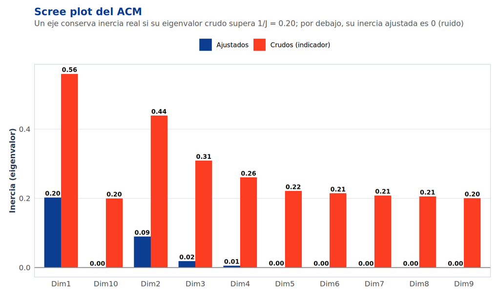

```r
plot_scree_mca(head(ejes_resumen, 10), registro$J_activas)
```

## 4.3 Interpretación del Dim1

```r
aporte <- tabla_categorias(res, tabla, ncp = 2, medida = "contrib")

aporte %>%
  filter(eje == "Dim1") %>%
  arrange(desc(valor)) %>%
  head(10) %>%
  select(nivel, variable, valor) %>%
  mutate(valor = paste0(round(valor, 1), "%")) %>%
  kable(caption = "Top 10 categorías por aporte al Dim1") %>%
  kable_styling(bootstrap_options = c("striped", "hover", "condensed"))
```

Top 10 categorías por aporte al Dim1

| nivel | variable | valor |
| --- | --- | --- |
| discoverymethod_Radial Velocity | discoverymethod | 19% |
| pl_bmassprov_Msini | pl_bmassprov | 17.5% |
| pl_bmassprov_Mass | pl_bmassprov | 9.7% |
| discoverymethod_Transit | discoverymethod | 9.5% |
| W. M. Keck Observatory | disc_facility | 5.8% |
| Sí | ttv_flag | 5.8% |
| Kepler | disc_facility | 5.4% |
| La Silla Observatory | disc_facility | 5.1% |
| discoverymethod_Microlensing | discoverymethod | 3.5% |
| st_metratio_Sin dato | st_metratio | 2.3% |

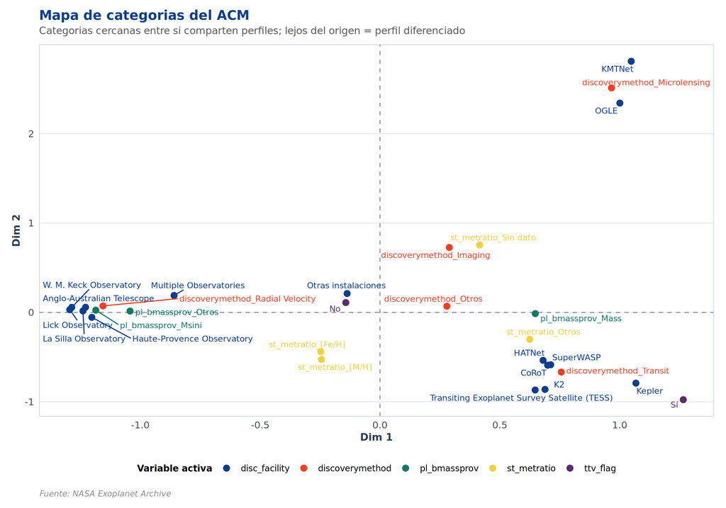

```r
plot_categorias_acm(res, tabla)
```

**Lectura del Dim1: el eje de cómo se obtuvo la masa.** El contraste principal no está entre planetas sino entre **estrategias de medición**:

- **Lado positivo:** el mundo de los tránsitos espaciales — `Kepler`, `K2`, `TESS`, `HATNet`, `SuperWASP`, `CoRoT` junto con `Transit`, con masa determinada como `Mass` (física, vía modelos) y con `Sí` en TTV. Son las filas donde la masa existe aunque el método principal no la mida directamente.
- **Lado negativo:** el mundo de la velocidad radial terrestre — `Radial Velocity` con `Msini` (masa mínima, depende de sin i), medidas en `W. M. Keck`, `Lick`, `La Silla`, `Anglo-Australian Telescope`, `Haute-Provence`, `Multiple Observatories`, y metalicidad **observada** con escala `[Fe/H]` / `[M/H]`.

La coherencia física es fuerte: los programas de RV seleccionan estrellas metálicas ricas (el sesgo bien documentado de que la metalicidad alta favorece la formación y detección de gigantes por RV), y su masa es `Msini` porque sin el tránsito no se conoce toda la inclinación orbital. En cambio, los tránsitos espaciales dan inclinación y por eso la masa aparece como `Mass` — además el nivel `Sí` de `ttv_flag` cae exactamente en ese lado: las variaciones de tiempo de tránsito solo existen en sistemas con tránsito.

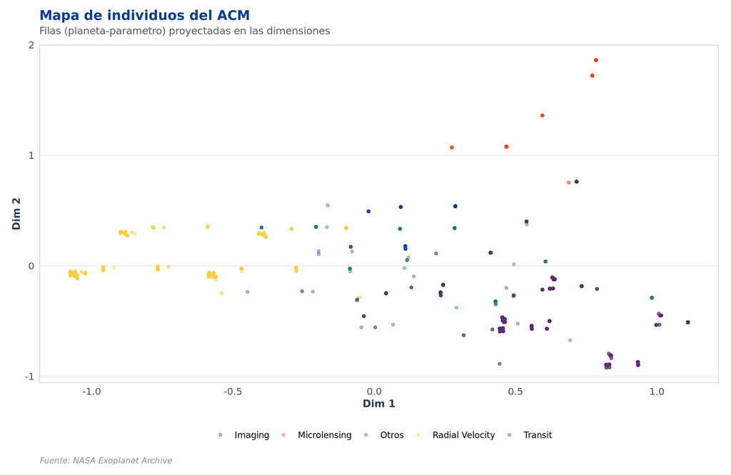

```r
plot_individuos_acm(res, grupo = tabla$discoverymethod)
```

El mapa de individuos confirma la separación sin solapamientos raros: las filas RV (amarillo) viven en el lado izquierdo/negativo, las de tránsito (púrpura) en el derecho/positivo, y las de microlente (rosa) quedan en la parte superior, que es justo lo que explica el Dim2.

## 4.4 Interpretación del Dim2

```r
aporte %>%
  filter(eje == "Dim2") %>%
  arrange(desc(valor)) %>%
  head(10) %>%
  select(nivel, variable, valor) %>%
  mutate(valor = paste0(round(valor, 1), "%")) %>%
  kable(caption = "Top 10 categorías por aporte al Dim2") %>%
  kable_styling(bootstrap_options = c("striped", "hover", "condensed"))
```

Top 10 categorías por aporte al Dim2

| nivel | variable | valor |
| --- | --- | --- |
| discoverymethod_Microlensing | discoverymethod | 30.3% |
| KMTNet | disc_facility | 15.4% |
| OGLE | disc_facility | 13.1% |
| st_metratio_Sin dato | st_metratio | 9.7% |
| discoverymethod_Transit | discoverymethod | 9.4% |
| st_metratio_[Fe/H] | st_metratio | 5.1% |
| Sí | ttv_flag | 4.4% |
| Kepler | disc_facility | 3.8% |
| Transiting Exoplanet Survey Satellite (TESS) | disc_facility | 3.5% |
| K2 | disc_facility | 1.4% |

## 4.5 Aportes por variable (agregando categorías)

```r
aporte %>%
  group_by(eje, variable) %>%
  summarise(aporte = sum(valor), .groups = "drop") %>%
  pivot_wider(names_from = eje, values_from = aporte) %>%
  mutate(Dim1 = paste0(round(Dim1, 1), "%"),
         Dim2 = paste0(round(Dim2, 1), "%")) %>%
  select(variable, Dim1, Dim2) %>%
  kable(caption = "Aporte por variable activa (suma de sus categorías)") %>%
  kable_styling(bootstrap_options = c("striped", "hover", "condensed"))
```

Aporte por variable activa (suma de sus categorías)

| variable | Dim1 | Dim2 |
| --- | --- | --- |
| disc_facility | 30.4% | 39.5% |
| discoverymethod | 32.1% | 40.2% |
| pl_bmassprov | 27.4% | 0% |
| st_metratio | 3.7% | 15.4% |
| ttv_flag | 6.4% | 4.9% |

`discoverymethod` y `disc_facility` dominan los dos ejes (son las variables con más niveles y mayor capacidad discriminatoria). `pl_bmassprov` es la tercera en importancia — y con sentido: describe *cómo se midió* la masa, que es exactamente el eje Dim1. `st_metratio` y `ttv_flag` aportan de forma secundaria pero no trivial.

# Fase 5 — Verificaciones y limitaciones

## La etiqueta “Sin dato” pesa, y así debe reportarse

```r
tab_met <- table(tabla$st_metratio)
tab_met_df <- as.data.frame(tab_met, responseName = "n")
names(tab_met_df) <- c("nivel", "n")
tab_met_df %>%
  mutate(pct = paste0(round(n / sum(n) * 100, 1), "%")) %>%
  kable(caption = "st_metratio: el nivel 'Sin dato' es ~1 de cada 3 filas") %>%
  kable_styling(bootstrap_options = c("striped", "hover", "condensed"))
```

st_metratio: el nivel ‘Sin dato’ es ~1 de cada 3 filas

| nivel | n | pct |
| --- | --- | --- |
| [Fe/H] | 3570 | 57.5% |
| [M/H] | 326 | 5.3% |
| Otros | 1 | 0% |
| Sin dato | 2310 | 37.2% |

## Niveles con n pequeño: posición inestable

Dos niveles agrupados tienen muestras mínimas y su posición en el mapa es referencial, no concluyente:

```r
dist_niveles %>%
  filter(n <= 30) %>%
  select(variable, nivel, n, pct) %>%
  mutate(pct = paste0(pct, "%")) %>%
  kable(caption = "Niveles con muestra mínima: leer con cautela") %>%
  kable_styling(bootstrap_options = c("striped", "hover", "condensed"))
```

Niveles con muestra mínima: leer con cautela

| variable | nivel | n | pct |
| --- | --- | --- | --- |
| pl_bmassprov | Otros | 26 | 0.4% |
| st_metratio | Otros | 1 | 0% |

`st_metratio_Otros` agrupa al único caso `[m/H]` (n = 1) y `pl_bmassprov_Otros` a los 26 casos `Msin(i)/sin(i)`. En un ACM un nivel con n pequeño puede alejarse del origen por pura rareza del perfil. Para el análisis principal no cambian nada (sus aportes son bajos), pero en la interpretación no se apoyan conclusiones en ellos.

## Unicidad de planeta en el subconjunto

Como en el ACP, la unidad es el **registro de parámetros**, no el planeta:

```r
tibble(
  concepto = c("Filas con masa (subset del ACM)",
               "Planetas únicos dentro del subset",
               "Filas por planeta (mediana / máximo)"),
  valor = c(registro$n_subset,
            n_distinct(sub_masa$pl_name),
            paste0(median(table(sub_masa$pl_name)), " / ", max(table(sub_masa$pl_name))))
) %>%
  kable(caption = "Unidad de análisis del ACM: registro con masa, no planeta") %>%
  kable_styling(bootstrap_options = c("striped", "hover", "condensed"))
```

Unidad de análisis del ACM: registro con masa, no planeta

| concepto | valor |
| --- | --- |
| Filas con masa (subset del ACM) | 6207 |
| Planetas únicos dentro del subset | 2848 |
| Filas por planeta (mediana / máximo) | 1 / 17 |

Un planeta con varias mediciones de masa publicadas participa varias veces. Es la misma limitación declarada en el ACP (sesgo de selección hacia planetas con masa) y aquí mantiene la comparabilidad entre los dos análisis.

# Conclusiones

1. **De 18 candidatas categóricas, 5 son activas viables** después de verificación con datos: `discoverymethod`, `disc_facility`, `pl_bmassprov`, `st_metratio`, `ttv_flag`. Las 13 excluidas se justifican una por una con evidencia del diagnóstico (identidad, continuidad disfrazada, nulos estructurales, constancia en el alcance, marcador de fila).
2. **El caso notable es `soltype`**: diseñada como activa (con colapso de sus 9 niveles), la verificación mostró que dentro del subconjunto con masa es 100% ‘Published Confirmed’ — varianza cero. Se excluye con evidencia y la función de colapso queda disponible para otro alcance.
3. **Dos ejes explican el 59,2% de la inercia ajustada**, con un codo claro en el tercero (3,8%).
4. **Dim1 es el eje de la técnica de medición de masa**: velocidad radial terrestre (`Msini`, telescopios de calibre grande, estrellas con metalicidad publicada) contra tránsito espacial (`Mass`, Kepler/K2/TESS, planetas con TTV). **Dim2 separa microlente e imagen** de las técnicas de tránsito.
5. El ACM y el ACP cuentan la misma historia por caminos distintos: la estructura de la población de exoplanetas con masa está primeramente marcada por **cómo se obtienen sus parámetros**, y eso arrastra los sesgos de detección (metallicidad en RV, inclinación orbital solo medible con tránsito).

## Cómo reproducir este análisis

```r
rmarkdown::render("ACM_Exoplanets.Rmd")
# La lógica vive en src/Functions_acm.R:
#   diagnostico_categoricas()  - diagnostico de viabilidad (18 candidatas)
#   preparar_categoricas()     - activas + tratamiento de niveles
#   correr_acm()               - FactoMineR::MCA con espectro completo
#   resumen_ejes_mca()         - eigenvalores crudos y ajustados (Greenacre)
#   tabla_categorias()         - aportes/cos2 con variable correcta
```